# Project "Wrangle and Analyze Data"

#### Author: Christoph Knoop

```python
# importing libraries
import pandas as pd
import numpy as np
import io
import os
import datetime
import matplotlib.pyplot as plt
import seaborn as sns
% matplotlib inline
import requests
import tweepy
import json
import time
```

## Step 1 - Gathering Data

### Loading the twitter-library of WeRateDogs

```python
# laoding the csv-File with the twitter-library into a pandas datafraem
df_library = pd.read_csv("twitter-archive-enhanced.csv", encoding="utf-8")

df_library.head()
```

|  | tweet_id | in_reply_to_status_id | in_reply_to_user_id | timestamp | source | text | retweeted_status_id | retweeted_status_user_id | retweeted_status_timestamp | expanded_urls | rating_numerator | rating_denominator | name | doggo | floofer | pupper | puppo |
| --- | --- | --- | --- | --- | --- | --- | --- | --- | --- | --- | --- | --- | --- | --- | --- | --- | --- |
| 0 | 892420643555336193 | NaN | NaN | 2017-08-01 16:23:56 +0000 | <a href="http://twitter.com/download/iphone" r... | This is Phineas. He's a mystical boy. Only eve... | NaN | NaN | NaN | https://twitter.com/dog_rates/status/892420643... | 13 | 10 | Phineas | None | None | None | None |
| 1 | 892177421306343426 | NaN | NaN | 2017-08-01 00:17:27 +0000 | <a href="http://twitter.com/download/iphone" r... | This is Tilly. She's just checking pup on you.... | NaN | NaN | NaN | https://twitter.com/dog_rates/status/892177421... | 13 | 10 | Tilly | None | None | None | None |
| 2 | 891815181378084864 | NaN | NaN | 2017-07-31 00:18:03 +0000 | <a href="http://twitter.com/download/iphone" r... | This is Archie. He is a rare Norwegian Pouncin... | NaN | NaN | NaN | https://twitter.com/dog_rates/status/891815181... | 12 | 10 | Archie | None | None | None | None |
| 3 | 891689557279858688 | NaN | NaN | 2017-07-30 15:58:51 +0000 | <a href="http://twitter.com/download/iphone" r... | This is Darla. She commenced a snooze mid meal... | NaN | NaN | NaN | https://twitter.com/dog_rates/status/891689557... | 13 | 10 | Darla | None | None | None | None |
| 4 | 891327558926688256 | NaN | NaN | 2017-07-29 16:00:24 +0000 | <a href="http://twitter.com/download/iphone" r... | This is Franklin. He would like you to stop ca... | NaN | NaN | NaN | https://twitter.com/dog_rates/status/891327558... | 12 | 10 | Franklin | None | None | None | None |

### Loading results of neuronal network

```python
# getting the document via requests
r = requests.get(" https://d17h27t6h515a5.cloudfront.net/topher/2017/August/599fd2ad_image-predictions/image-predictions.tsv")
print(r.status_code)
```

```
200
```

```python
# commute tsv-file into pd-Dataframe
df_dogs = pd.read_csv(io.StringIO(r.content.decode("utf-8")), sep="\t")
df_dogs.to_csv("image_prediction.tsv", sep='\t')
```

### Loading additional information via the Twitter-API

```python
# perparing API
consumer_key = 'QkGmiHV2F12MikMnLUvLIhsCi'
consumer_secret = 'qRYDW1bd2Qnv04lObZ8n8xi1rRCBqZQRvxc357EmrIWUvYb2ce'

access_token = '465635051-GkW3GrYZ96Sv7p7d9c3bYMNV59GkEhnUVLqGOPOm'
access_secret = 'EFnorpaMHDoKsECFQ8vnexh8XtC2dCn91HzqjRtVxLV25'

auth = tweepy.OAuthHandler(consumer_key, consumer_secret)
auth.set_access_token(access_token, access_secret)

api = tweepy.API(auth, wait_on_rate_limit=True, wait_on_rate_limit_notify=True)
```

```python
# code was commented out after the first call

# creating txt-doc by calling Twitter-API
#file_name = "tweet_json.txt"

#start=time.time()
#with open(file_name, "w") as outfile:
    #for elem in df_library["tweet_id"]:

        #try:

            #tweet = api.get_status(elem)
            #json.dump(tweet._json, outfile)
            #outfile.write("\n")
        #except tweepy.TweepError as e:
            #print ("Fehlermeldung bei ID:", elem, " Code: ", e.args [0])
        #end=time.time()
        #print("running:", round(end-start,2), " seconds")
```

[output not shown]

[output cut: 2316 more lines]

[output not shown]

```python
# creating pd-dataframe from txt-file
file_name = "tweet_json.txt"
rows_list =[]
with open(file_name, "r") as file:
    for line in file:
        data = json.loads(line)
        tweet_dict = {
            "tweet_id": data["id"],
            "retweet_count": data["retweet_count"],
            "favorite_count": data["favorite_count"]
        }
        rows_list.append(tweet_dict)

df_tweepy = pd.DataFrame(rows_list)
df_tweepy.head()
```

|  | favorite_count | retweet_count | tweet_id |
| --- | --- | --- | --- |
| 0 | 38925 | 8627 | 892420643555336193 |
| 1 | 33327 | 6337 | 892177421306343426 |
| 2 | 25108 | 4207 | 891815181378084864 |
| 3 | 42278 | 8749 | 891689557279858688 |
| 4 | 40436 | 9508 | 891327558926688256 |

## Step 2 - Assessing Data

### Checking the Twitter archive of WeRateDogs

```python
df_library.info()
```

```
<class 'pandas.core.frame.DataFrame'>
RangeIndex: 2356 entries, 0 to 2355
Data columns (total 17 columns):
tweet_id                      2356 non-null int64
in_reply_to_status_id         78 non-null float64
in_reply_to_user_id           78 non-null float64
timestamp                     2356 non-null object
source                        2356 non-null object
text                          2356 non-null object
retweeted_status_id           181 non-null float64
retweeted_status_user_id      181 non-null float64
retweeted_status_timestamp    181 non-null object
expanded_urls                 2297 non-null object
rating_numerator              2356 non-null int64
rating_denominator            2356 non-null int64
name                          2356 non-null object
doggo                         2356 non-null object
floofer                       2356 non-null object
pupper                        2356 non-null object
puppo                         2356 non-null object
dtypes: float64(4), int64(3), object(10)
memory usage: 313.0+ KB
```

**Quality-issues:**

- Tweet-id ist an integer, should be string.
- Timestamp is a string, should be a datetime-object.
- Expanded_urls has missing values

**Tidiness-issues:**

- unnecessary variables: in_reply_to_status_id, in_reply_to_user_id, retweeted_status_user_id, retweeted_status_timestamp
- dog type is not tidy, better: one Variable "dog_type" with the individual description as value
- putting variables in two tables, one with dognames, breeds and dogtypes, the other with all twitter-related informations

```python
df_library.sample(15)
```

|  | tweet_id | in_reply_to_status_id | in_reply_to_user_id | timestamp | source | text | retweeted_status_id | retweeted_status_user_id | retweeted_status_timestamp | expanded_urls | rating_numerator | rating_denominator | name | doggo | floofer | pupper | puppo |
| --- | --- | --- | --- | --- | --- | --- | --- | --- | --- | --- | --- | --- | --- | --- | --- | --- | --- |
| 461 | 817536400337801217 | NaN | NaN | 2017-01-07 01:00:41 +0000 | <a href="http://twitter.com/download/iphone" r... | Say hello to Eugene &amp; Patti Melt. No matte... | NaN | NaN | NaN | https://twitter.com/dog_rates/status/817536400... | 12 | 10 | Eugene | None | None | None | None |
| 1547 | 689280876073582592 | NaN | NaN | 2016-01-19 02:59:01 +0000 | <a href="http://twitter.com/download/iphone" r... | This is Herald. He wants you to know he could ... | NaN | NaN | NaN | https://twitter.com/dog_rates/status/689280876... | 10 | 10 | Herald | None | None | None | None |
| 2058 | 671347597085433856 | NaN | NaN | 2015-11-30 15:18:34 +0000 | <a href="http://twitter.com/download/iphone" r... | This is Lola. She was not fully prepared for t... | NaN | NaN | NaN | https://twitter.com/dog_rates/status/671347597... | 9 | 10 | Lola | None | None | None | None |
| 429 | 821107785811234820 | NaN | NaN | 2017-01-16 21:32:06 +0000 | <a href="http://twitter.com/download/iphone" r... | Here's a doggo who looks like he's about to gi... | NaN | NaN | NaN | https://twitter.com/dog_rates/status/821107785... | 11 | 10 | None | doggo | None | None | None |
| 708 | 785264754247995392 | NaN | NaN | 2016-10-09 23:44:41 +0000 | <a href="http://twitter.com/download/iphone" r... | This is Doc. He requested to be carried around... | NaN | NaN | NaN | https://twitter.com/dog_rates/status/785264754... | 12 | 10 | Doc | None | None | None | None |
| 2238 | 668113020489474048 | NaN | NaN | 2015-11-21 17:05:31 +0000 | <a href="http://twitter.com/download/iphone" r... | This is Alfie. He's that one hypocritical gym ... | NaN | NaN | NaN | https://twitter.com/dog_rates/status/668113020... | 6 | 10 | Alfie | None | None | None | None |
| 1080 | 738891149612572673 | 7.384119e+17 | 358972768.0 | 2016-06-04 00:32:32 +0000 | <a href="http://twitter.com/download/iphone" r... | @mount_alex3 13/10 | NaN | NaN | NaN | NaN | 13 | 10 | None | None | None | None | None |
| 1591 | 686606069955735556 | NaN | NaN | 2016-01-11 17:50:18 +0000 | <a href="http://twitter.com/download/iphone" r... | Meet Horace. He was practicing his levitation,... | NaN | NaN | NaN | https://twitter.com/dog_rates/status/686606069... | 10 | 10 | Horace | None | None | None | None |
| 213 | 851591660324737024 | NaN | NaN | 2017-04-11 00:24:08 +0000 | <a href="http://twitter.com/download/iphone" r... | Oh jeez u did me quite the spook little fella.... | NaN | NaN | NaN | https://twitter.com/dog_rates/status/851591660... | 11 | 10 | None | None | None | None | None |
| 1704 | 680889648562991104 | NaN | NaN | 2015-12-26 23:15:17 +0000 | <a href="http://twitter.com/download/iphone" r... | This is Cheesy. It's her birthday. She's patie... | NaN | NaN | NaN | https://twitter.com/dog_rates/status/680889648... | 9 | 10 | Cheesy | None | None | None | None |
| 1108 | 734559631394082816 | NaN | NaN | 2016-05-23 01:40:38 +0000 | <a href="http://vine.co" rel="nofollow">Vine -... | When your friend is turnt af and you're just t... | NaN | NaN | NaN | https://vine.co/v/iExiLXiiHvX | 10 | 10 | None | None | None | None | None |
| 1387 | 700505138482569216 | NaN | NaN | 2016-02-19 02:20:14 +0000 | <a href="http://twitter.com/download/iphone" r... | This is Kaia. She's just cute as hell. 12/10 I... | NaN | NaN | NaN | https://twitter.com/dog_rates/status/700505138... | 12 | 10 | Kaia | None | None | None | None |
| 2213 | 668567822092664832 | NaN | NaN | 2015-11-22 23:12:44 +0000 | <a href="http://twitter.com/download/iphone" r... | This is Marvin. He can tie a bow tie better th... | NaN | NaN | NaN | https://twitter.com/dog_rates/status/668567822... | 11 | 10 | Marvin | None | None | None | None |
| 450 | 818646164899774465 | NaN | NaN | 2017-01-10 02:30:30 +0000 | <a href="http://twitter.com/download/iphone" r... | RT @dog_rates: This is Seamus. He's very bad a... | 8.083449e+17 | 4.196984e+09 | 2016-12-12 16:16:49 +0000 | https://vine.co/v/5QWd3LZqXxd,https://vine.co/... | 11 | 10 | Seamus | None | None | None | None |
| 246 | 845677943972139009 | NaN | NaN | 2017-03-25 16:45:08 +0000 | <a href="http://twitter.com/download/iphone" r... | C'mon guys. Please only send in dogs. We only ... | NaN | NaN | NaN | https://twitter.com/dog_rates/status/845677943... | 12 | 10 | None | None | None | None | None |

**Quality-issues**

- delete rows with retweeted_status_id != NaN to avoid analyzing retweets
- delete rows without expanded url, only tweets with picture are acceptable

```python
df_library["rating_numerator"].value_counts()
```

```
12      558
11      464
10      461
13      351
9       158
8       102
7        55
14       54
5        37
6        32
3        19
4        17
1         9
2         9
420       2
```

[output cut: 26 more lines]

**Quality issue**

- have to check the very high values >= 100

```python
# checking for wrong names
df_library[df_library['name'].str.len() < 3]["name"].value_counts()
```

```
a     55
Bo     9
an     7
Ed     1
Mo     1
Al     1
my     1
JD     1
by     1
Jo     1
O      1
Name: name, dtype: int64
```

**Quality issues**:

- deleting wrong names like a, an, the, by, my and checking text if real name is included
- checking Name "O"

### Checking the data of the neuronal network (df_dogs)

```python
print(df_dogs.sample(20))
```

```
                tweet_id                                            jpg_url  \
1367  761745352076779520    https://pbs.twimg.com/media/CpJDWqhW8AAFt45.jpg
31    666421158376562688    https://pbs.twimg.com/media/CT-aggCXAAIMfT3.jpg
619   680440374763077632  https://pbs.twimg.com/ext_tw_video_thumb/68044...
548   677334615166730240    https://pbs.twimg.com/media/CWZgPPUWUAAUOvu.jpg
1779  828409743546925057    https://pbs.twimg.com/media/C38aQYgXAAMY2Wh.jpg
1508  785872687017132033  https://pbs.twimg.com/ext_tw_video_thumb/78587...
1524  788178268662984705    https://pbs.twimg.com/media/CvAr88kW8AEKNAO.jpg
1974  869772420881756160    https://pbs.twimg.com/media/DBINZcxXgAQ-R6P.jpg
133   668480044826800133    https://pbs.twimg.com/media/CUbrDWOWcAEyMdM.jpg
1469  779056095788752897    https://pbs.twimg.com/media/Cs_DYr1XEAA54Pu.jpg
694   684241637099323392    https://pbs.twimg.com/media/CX7qIcdWcAELJ7N.jpg
573   678424312106393600    https://pbs.twimg.com/media/CWo_T8gW4AAgJNo.jpg
1299  752519690950500352    https://pbs.twimg.com/media/CnF8qVDWYAAh0g1.jpg
1553  793165685325201412    https://pbs.twimg.com/media/CwHj-jGWAAAnsny.jpg
```

[output cut: 50 more lines]

**Quality issues:**

```python
df_dogs.info()
```

```
<class 'pandas.core.frame.DataFrame'>
RangeIndex: 2075 entries, 0 to 2074
Data columns (total 12 columns):
tweet_id    2075 non-null int64
jpg_url     2075 non-null object
img_num     2075 non-null int64
p1          2075 non-null object
p1_conf     2075 non-null float64
p1_dog      2075 non-null bool
p2          2075 non-null object
p2_conf     2075 non-null float64
p2_dog      2075 non-null bool
p3          2075 non-null object
p3_conf     2075 non-null float64
p3_dog      2075 non-null bool
dtypes: bool(3), float64(3), int64(2), object(4)
memory usage: 152.1+ KB
```

**Quality issues:**

- tweet_id should be string, not integer

```python
df_dogs["p1"].value_counts()
```

```
golden_retriever             150
Labrador_retriever           100
Pembroke                      89
Chihuahua                     83
pug                           57
chow                          44
Samoyed                       43
toy_poodle                    39
Pomeranian                    38
cocker_spaniel                30
malamute                      30
French_bulldog                26
miniature_pinscher            23
Chesapeake_Bay_retriever      23
seat_belt                     22
Siberian_husky                20
German_shepherd               20
Staffordshire_bullterrier     20
web_site                      19
Cardigan                      19
Shetland_sheepdog             18
teddy                         18
beagle                        18
Maltese_dog                   18
Eskimo_dog                    18
Lakeland_terrier              17
Shih-Tzu                      17
Rottweiler                    17
kuvasz                        16
Italian_greyhound             16
                            ...
hand_blower                    1
remote_control                 1
teapot                         1
coffee_mug                     1
ice_lolly                      1
zebra                          1
carton                         1
mailbox                        1
sandbar                        1
microphone                     1
marmot                         1
long-horned_beetle             1
basketball                     1
lion                           1
book_jacket                    1
king_penguin                   1
ibex                           1
hare                           1
pillow                         1
pedestal                       1
scorpion                       1
lynx                           1
Madagascar_cat                 1
beach_wagon                    1
syringe                        1
harp                           1
water_bottle                   1
hammer                         1
coral_reef                     1
bookcase                       1
Name: p1, Length: 378, dtype: int64
```

### Examine Data of the Twitter-API

```python
df_tweepy.info()
```

```
<class 'pandas.core.frame.DataFrame'>
RangeIndex: 2343 entries, 0 to 2342
Data columns (total 3 columns):
favorite_count    2343 non-null int64
retweet_count     2343 non-null int64
tweet_id          2343 non-null int64
dtypes: int64(3)
memory usage: 55.0 KB
```

**Quality issue**:

- tweed_id should be string instead of integer

## Clean Data

These are some of the problems we identified in the data sets:

**TIDINESS**

1. remove unnecessary variables in twitter-archive: in_reply_to_status_id, in_reply_to_user_id, retweeted_status_user_id, retweeted_status_timestamp X
2. dog type is not tidy, better: one Variable "dog_type" with the individual description as value
3. find the best answer of the neural network to the question about the dog breed
4. putting variables in two tables, one with dognames, breeds and dogtypes, the other with all twitter-related informations
5. deleting unnecessary variables, means: all variables except Twitter ID, p1, p1_conf

**QUALITY**:

1. Tweet-id ist an integer, should be string (in all tables)
2. Timestamp is a string, should be a datetime-object.
3. delete expanded_urls with missing values
4. delete rows with retweeted_status_id != NaN to avoid analyzing retweets
5. rating: have to check the very high values >= 100
6. deleting wrong names like a, an, the, by, my and checking text if real name is included
7. checking Name "O"
8. standardizing dog breed names: sometimes the names of the breeds are written in uppercase, sometimes in lowercase. We also want to replace underscores with spaces.
9. Changge dog breeds to categorical variables

```python
# creating copys of the dataframes
lib_copy = df_library.copy()
dog_copy = df_dogs.copy()
#twitter_copy = df_twitter.copy()
```

### TIDINESS

```python
# in lib_copy, delete source, in_reply_to_status_id, in_reply_to_user_id, retweeted_status_user_id, retweeted_status_timestamp
lib_copy.drop(["source", "in_reply_to_status_id", "in_reply_to_user_id",
               "retweeted_status_user_id", "retweeted_status_timestamp"], axis=1, inplace=True)
lib_copy.head(1)
```

|  | tweet_id | timestamp | text | retweeted_status_id | expanded_urls | rating_numerator | rating_denominator | name | doggo | floofer | pupper | puppo |
| --- | --- | --- | --- | --- | --- | --- | --- | --- | --- | --- | --- | --- |
| 0 | 892420643555336193 | 2017-08-01 16:23:56 +0000 | This is Phineas. He's a mystical boy. Only eve... | NaN | https://twitter.com/dog_rates/status/892420643... | 13 | 10 | Phineas | None | None | None | None |

#### finding best result for dog breed in data of the neural network

If the neural network found a dog breed at the first hit, it is inserted into the data set under the variable "dog". Otherwise, the system checks whether the neural network was able to land a hit at position 2 or 3. For any questions that may arise during the analysis, the probability with which the identified dog breed can actually be seen on the photo is also included in the data set.

```python
# finding the best dog-related solution of the neuronal network
def dogtest(x):
    if x["p1_dog"] == True:
        return pd.Series ([x["p1"], x["p1_conf"]])
    elif x["p2_dog"] == True:
        return pd.Series ([x["p2"], x["p2_conf"]])
    elif x["p3_dog"] == True:
        return pd.Series ([x["p3"], x["p3_conf"]])
    else:
        return pd.Series ([None, None])

dog_copy[["dog", "dog_prob"]] = dog_copy.apply(dogtest, axis=1)
```

```python
#  get rid of the unnecessasry columns in dog_copy
dog_copy = dog_copy[["tweet_id", "dog", "dog_prob"]]
```

```python
#testing the result
dog_copy.head()
```

|  | tweet_id | dog | dog_prob |
| --- | --- | --- | --- |
| 0 | 666020888022790149 | Welsh_springer_spaniel | 0.465074 |
| 1 | 666029285002620928 | redbone | 0.506826 |
| 2 | 666033412701032449 | German_shepherd | 0.596461 |
| 3 | 666044226329800704 | Rhodesian_ridgeback | 0.408143 |
| 4 | 666049248165822465 | miniature_pinscher | 0.560311 |

#### Making the data of dog_types tidy

The data of the respective dog type (doggo, floofer, pupper, puppo) in the Twitter archive are not tidy. Instead of having a separate column for each dog type, we create the variable dog_type, under which the respective dog type is listed. If no dog type is specified, a "None" is entered.

```python
lib_copy.shape
```

```
(2356, 12)
```

```python
lib_copy.head(1)
```

|  | tweet_id | timestamp | text | retweeted_status_id | expanded_urls | rating_numerator | rating_denominator | name | doggo | floofer | pupper | puppo |
| --- | --- | --- | --- | --- | --- | --- | --- | --- | --- | --- | --- | --- |
| 0 | 892420643555336193 | 2017-08-01 16:23:56 +0000 | This is Phineas. He's a mystical boy. Only eve... | NaN | https://twitter.com/dog_rates/status/892420643... | 13 | 10 | Phineas | None | None | None | None |

```python
# first we have to check for every row, if any of the dog-type-variables is filled out.
# If not, we are setting the variable dog_type to "None"

def check_dog_type(x):

    if x["doggo"] != "None":
        return "doggo"
    elif x["floofer"] != "None":
        return "floofer"
    elif x["pupper"] != "None":
        return "pupper"
    elif x["puppo"] != "None":
        return "puppo"
    else:
        return "None"

lib_copy["dog_type"] = lib_copy.apply(check_dog_type, axis=1)
```

```python
# delete the unnecessary rows doggo, floofer, pupper, puppo
lib_copy.drop(["doggo", "floofer", "pupper", "puppo"], axis=1, inplace=True)
```

```python
lib_copy.head()
```

|  | tweet_id | timestamp | text | retweeted_status_id | expanded_urls | rating_numerator | rating_denominator | name | dog_type |
| --- | --- | --- | --- | --- | --- | --- | --- | --- | --- |
| 0 | 892420643555336193 | 2017-08-01 16:23:56 +0000 | This is Phineas. He's a mystical boy. Only eve... | NaN | https://twitter.com/dog_rates/status/892420643... | 13 | 10 | Phineas | None |
| 1 | 892177421306343426 | 2017-08-01 00:17:27 +0000 | This is Tilly. She's just checking pup on you.... | NaN | https://twitter.com/dog_rates/status/892177421... | 13 | 10 | Tilly | None |
| 2 | 891815181378084864 | 2017-07-31 00:18:03 +0000 | This is Archie. He is a rare Norwegian Pouncin... | NaN | https://twitter.com/dog_rates/status/891815181... | 12 | 10 | Archie | None |
| 3 | 891689557279858688 | 2017-07-30 15:58:51 +0000 | This is Darla. She commenced a snooze mid meal... | NaN | https://twitter.com/dog_rates/status/891689557... | 13 | 10 | Darla | None |
| 4 | 891327558926688256 | 2017-07-29 16:00:24 +0000 | This is Franklin. He would like you to stop ca... | NaN | https://twitter.com/dog_rates/status/891327558... | 12 | 10 | Franklin | None |

#### Merging Data

Now we merge our three tables into two tables. Table 1 lib_copy contains all Twitter relevant information. Table 2 (dogs) collects all dog information.

For the twitter-dataframe we are choosing an left join to process the tweets that are no longer in the Twitter database. In this case pandas converts the two variables "favorite_count" and "retweet_count" into floats, which we have to transform back into int later.

```python
twitter = pd.merge(lib_copy, df_tweepy, how="left", on="tweet_id")
```

```python
twitter.shape
```

```
(2356, 11)
```

```python
twitter.head()
```

|  | tweet_id | timestamp | text | retweeted_status_id | expanded_urls | rating_numerator | rating_denominator | name | dog_type | favorite_count | retweet_count |
| --- | --- | --- | --- | --- | --- | --- | --- | --- | --- | --- | --- |
| 0 | 892420643555336193 | 2017-08-01 16:23:56 +0000 | This is Phineas. He's a mystical boy. Only eve... | NaN | https://twitter.com/dog_rates/status/892420643... | 13 | 10 | Phineas | None | 38925.0 | 8627.0 |
| 1 | 892177421306343426 | 2017-08-01 00:17:27 +0000 | This is Tilly. She's just checking pup on you.... | NaN | https://twitter.com/dog_rates/status/892177421... | 13 | 10 | Tilly | None | 33327.0 | 6337.0 |
| 2 | 891815181378084864 | 2017-07-31 00:18:03 +0000 | This is Archie. He is a rare Norwegian Pouncin... | NaN | https://twitter.com/dog_rates/status/891815181... | 12 | 10 | Archie | None | 25108.0 | 4207.0 |
| 3 | 891689557279858688 | 2017-07-30 15:58:51 +0000 | This is Darla. She commenced a snooze mid meal... | NaN | https://twitter.com/dog_rates/status/891689557... | 13 | 10 | Darla | None | 42278.0 | 8749.0 |
| 4 | 891327558926688256 | 2017-07-29 16:00:24 +0000 | This is Franklin. He would like you to stop ca... | NaN | https://twitter.com/dog_rates/status/891327558... | 12 | 10 | Franklin | None | 40436.0 | 9508.0 |

```python
dogs = pd.merge(dog_copy, lib_copy[["name", "dog_type", "tweet_id"]], how="left", on="tweet_id")
```

```python
dogs.tail(15)
```

|  | tweet_id | dog | dog_prob | name | dog_type |
| --- | --- | --- | --- | --- | --- |
| 2060 | 889531135344209921 | golden_retriever | 0.953442 | Stuart | puppo |
| 2061 | 889638837579907072 | French_bulldog | 0.991650 | Ted | None |
| 2062 | 889665388333682689 | Pembroke | 0.966327 | None | puppo |
| 2063 | 889880896479866881 | French_bulldog | 0.377417 | Bruno | None |
| 2064 | 890006608113172480 | Samoyed | 0.957979 | Koda | None |
| 2065 | 890240255349198849 | Pembroke | 0.511319 | Cassie | doggo |
| 2066 | 890609185150312448 | Irish_terrier | 0.487574 | Zoey | None |
| 2067 | 890729181411237888 | Pomeranian | 0.566142 | None | None |
| 2068 | 890971913173991426 | Appenzeller | 0.341703 | Jax | None |
| 2069 | 891087950875897856 | Chesapeake_Bay_retriever | 0.425595 | None | None |
| 2070 | 891327558926688256 | basset | 0.555712 | Franklin | None |
| 2071 | 891689557279858688 | Labrador_retriever | 0.168086 | Darla | None |
| 2072 | 891815181378084864 | Chihuahua | 0.716012 | Archie | None |
| 2073 | 892177421306343426 | Chihuahua | 0.323581 | Tilly | None |
| 2074 | 892420643555336193 | None | NaN | Phineas | None |

```python
dogs.shape
```

```
(2075, 5)
```

```python
# deleting dogrelated information from our twitter-dataframe, so we don´t have same columns in two dataframes
twitter.drop(["name", "dog_type"], axis=1, inplace=True)
```

```python
twitter.head(1)
```

|  | tweet_id | timestamp | text | retweeted_status_id | expanded_urls | rating_numerator | rating_denominator | favorite_count | retweet_count |
| --- | --- | --- | --- | --- | --- | --- | --- | --- | --- |
| 0 | 892420643555336193 | 2017-08-01 16:23:56 +0000 | This is Phineas. He's a mystical boy. Only eve... | NaN | https://twitter.com/dog_rates/status/892420643... | 13 | 10 | 38925.0 | 8627.0 |

### QUALITY

#### Changing datatypes

```python
#twitter - changing columns "tweet_id" form integer to string
twitter.tweet_id = twitter.tweet_id.astype(str)
```

```python
#twitter - changing columns "favorite_count" and "retweet_count" fromfloat to integer
twitter.favorite_count = twitter.favorite_count.fillna(0).astype(int)
twitter.retweet_count = twitter.favorite_count.fillna(0).astype(int)
```

```python
#twitter - changing timestamp into datetime-object
twitter["timestamp"] = pd.to_datetime(twitter["timestamp"], format="%Y-%m-%d %H:%M:%S")
```

```python
# Test of the new datatypes
twitter.dtypes
```

```
tweet_id                       object
timestamp              datetime64[ns]
text                           object
retweeted_status_id           float64
expanded_urls                  object
rating_numerator                int64
rating_denominator              int64
favorite_count                  int32
retweet_count                   int32
dtype: object
```

```python
# Changing tweet_id in dogs-Dataframe
dogs.tweet_id = dogs.tweet_id.astype(str)
```

#### Standardizing dog breed names

```python
# replace _ with space
# title() = every word starts with capital letters
dogs["dog"] = dogs["dog"].str.replace("_", " ").str.title()
```

```python
# testing dog breed names
dogs.head()
```

|  | tweet_id | dog | dog_prob | name | dog_type |
| --- | --- | --- | --- | --- | --- |
| 0 | 666020888022790149 | Welsh Springer Spaniel | 0.465074 | None | None |
| 1 | 666029285002620928 | Redbone | 0.506826 | a | None |
| 2 | 666033412701032449 | German Shepherd | 0.596461 | a | None |
| 3 | 666044226329800704 | Rhodesian Ridgeback | 0.408143 | a | None |
| 4 | 666049248165822465 | Miniature Pinscher | 0.560311 | None | None |

#### Deleting rows with missing expanded-Url-Data

We would like for our analysis only tweets with photos/videos and have so for to delete 59 rows with NaN as expanded_urls

```python
twitter.expanded_urls.isnull().sum()
```

```
59
```

```python
twitter.shape
```

```
(2356, 9)
```

```python
twitter.dropna(subset=["expanded_urls"], inplace=True)
```

```python
twitter.shape
```

```
(2297, 9)
```

```python
twitter.head(1)
```

|  | tweet_id | timestamp | text | retweeted_status_id | expanded_urls | rating_numerator | rating_denominator | favorite_count | retweet_count |
| --- | --- | --- | --- | --- | --- | --- | --- | --- | --- |
| 0 | 892420643555336193 | 2017-08-01 16:23:56 | This is Phineas. He's a mystical boy. Only eve... | NaN | https://twitter.com/dog_rates/status/892420643... | 13 | 10 | 38925 | 38925 |

#### Deleting retweets by deleting rows where retweeted_status_id != NaN

```python
#Determine the number of rows affected
twitter.retweeted_status_id.notnull().sum()
```

```
180
```

```python
#Limit data set to rows with value=NaN
twitter = twitter[twitter["retweeted_status_id"].isnull()]
```

```python
# Deleting the column "retweeted_status_id
twitter.drop(["retweeted_status_id"], axis=1, inplace=True)
```

```python
twitter.shape
```

```
(2117, 8)
```

#### Check very high values of rating (more than three digits)

```python
# First we refresh the index in order to be able to access and delete the identified lines later with.index().
twitter.reset_index(drop=True, inplace=True)
```

```python
# We identify all series in which the value of the rating_numerator is at least 100 or greater.
df_rating = twitter[(twitter["rating_numerator"] >= 100)]
```

```python
df_rating.head(10)
```

|  | tweet_id | timestamp | text | expanded_urls | rating_numerator | rating_denominator | favorite_count | retweet_count |
| --- | --- | --- | --- | --- | --- | --- | --- | --- |
| 702 | 758467244762497024 | 2016-07-28 01:00:57 | Why does this never happen at my front door...... | https://twitter.com/dog_rates/status/758467244... | 165 | 150 | 5217 | 5217 |
| 772 | 749981277374128128 | 2016-07-04 15:00:45 | This is Atticus. He's quite simply America af.... | https://twitter.com/dog_rates/status/749981277... | 1776 | 10 | 5521 | 5521 |
| 908 | 731156023742988288 | 2016-05-13 16:15:54 | Say hello to this unbelievably well behaved sq... | https://twitter.com/dog_rates/status/731156023... | 204 | 170 | 4109 | 4109 |
| 1410 | 684225744407494656 | 2016-01-05 04:11:44 | Two sneaky puppers were not initially seen, mo... | https://twitter.com/dog_rates/status/684225744... | 143 | 130 | 1335 | 1335 |
| 1411 | 684222868335505415 | 2016-01-05 04:00:18 | Someone help the girl is being mugged. Several... | https://twitter.com/dog_rates/status/684222868... | 121 | 110 | 4134 | 4134 |
| 1552 | 677716515794329600 | 2015-12-18 05:06:23 | IT'S PUPPERGEDDON. Total of 144/120 ...I think... | https://twitter.com/dog_rates/status/677716515... | 144 | 120 | 3245 | 3245 |
| 1840 | 670842764863651840 | 2015-11-29 05:52:33 | After so many requests... here you go.\n\nGood... | https://twitter.com/dog_rates/status/670842764... | 420 | 10 | 25589 | 25589 |

```python
# For a more detailed examination of the values we need the complete text.
list(df_rating.text)
```

```
['Why does this never happen at my front door... 165/150 https://t.co/HmwrdfEfUE',
 "This is Atticus. He's quite simply America af. 1776/10 https://t.co/GRXwMxLBkh",
 'Say hello to this unbelievably well behaved squad of doggos. 204/170 would try to pet all at once https://t.co/yGQI3He3xv',
 'Two sneaky puppers were not initially seen, moving the rating to 143/130. Please forgive us. Thank you https://t.co/kRK51Y5ac3',
 'Someone help the girl is being mugged. Several are distracting her while two steal her shoes. Clever puppers 121/110 https://t.co/1zfnTJLt55',
 "IT'S PUPPERGEDDON. Total of 144/120 ...I think https://t.co/ZanVtAtvIq",
 'After so many requests... here you go.\n\nGood dogg. 420/10 https://t.co/yfAAo1gdeY']
```

```python
# Only in the second and the last row we find the typical valuation pattern.
# The other evaluations have been submitted as mentioned by the site operator.
# However, for analysis purposes, we delete them from our data set.
twitter.drop(twitter.index[[702, 908, 1410, 1411, 1552]], inplace=True)
```

```python
# Test if the rows have been deleted as desired.
twitter[twitter["rating_numerator"]>=100]
```

|  | tweet_id | timestamp | text | expanded_urls | rating_numerator | rating_denominator | favorite_count | retweet_count |
| --- | --- | --- | --- | --- | --- | --- | --- | --- |
| 772 | 749981277374128128 | 2016-07-04 15:00:45 | This is Atticus. He's quite simply America af.... | https://twitter.com/dog_rates/status/749981277... | 1776 | 10 | 5521 | 5521 |
| 1840 | 670842764863651840 | 2015-11-29 05:52:33 | After so many requests... here you go.\n\nGood... | https://twitter.com/dog_rates/status/670842764... | 420 | 10 | 25589 | 25589 |

```python
twitter[twitter["rating_denominator"] != 10]
```

|  | tweet_id | timestamp | text | expanded_urls | rating_numerator | rating_denominator | favorite_count | retweet_count |
| --- | --- | --- | --- | --- | --- | --- | --- | --- |
| 341 | 820690176645140481 | 2017-01-15 17:52:40 | The floofs have been released I repeat the flo... | https://twitter.com/dog_rates/status/820690176... | 84 | 70 | 13295 | 13295 |
| 405 | 810984652412424192 | 2016-12-19 23:06:23 | Meet Sam. She smiles 24/7 &amp; secretly aspir... | https://www.gofundme.com/sams-smile,https://tw... | 24 | 7 | 5835 | 5835 |
| 857 | 740373189193256964 | 2016-06-08 02:41:38 | After so many requests, this is Bretagne. She ... | https://twitter.com/dog_rates/status/740373189... | 9 | 11 | 37243 | 37243 |
| 953 | 722974582966214656 | 2016-04-21 02:25:47 | Happy 4/20 from the squad! 13/10 for all https... | https://twitter.com/dog_rates/status/722974582... | 4 | 20 | 4393 | 4393 |
| 990 | 716439118184652801 | 2016-04-03 01:36:11 | This is Bluebert. He just saw that both #Final... | https://twitter.com/dog_rates/status/716439118... | 50 | 50 | 2524 | 2524 |
| 1016 | 713900603437621249 | 2016-03-27 01:29:02 | Happy Saturday here's 9 puppers on a bench. 99... | https://twitter.com/dog_rates/status/713900603... | 99 | 90 | 3017 | 3017 |
| 1041 | 710658690886586372 | 2016-03-18 02:46:49 | Here's a brigade of puppers. All look very pre... | https://twitter.com/dog_rates/status/710658690... | 80 | 80 | 2468 | 2468 |
| 1061 | 709198395643068416 | 2016-03-14 02:04:08 | From left to right:\nCletus, Jerome, Alejandro... | https://twitter.com/dog_rates/status/709198395... | 45 | 50 | 2580 | 2580 |
| 1136 | 704054845121142784 | 2016-02-28 21:25:30 | Here is a whole flock of puppers. 60/50 I'll ... | https://twitter.com/dog_rates/status/704054845... | 60 | 50 | 3138 | 3138 |
| 1218 | 697463031882764288 | 2016-02-10 16:51:59 | Happy Wednesday here's a bucket of pups. 44/40... | https://twitter.com/dog_rates/status/697463031... | 44 | 40 | 3667 | 3667 |
| 1438 | 682962037429899265 | 2016-01-01 16:30:13 | This is Darrel. He just robbed a 7/11 and is i... | https://twitter.com/dog_rates/status/682962037... | 7 | 11 | 39858 | 39858 |
| 1615 | 675853064436391936 | 2015-12-13 01:41:41 | Here we have an entire platoon of puppers. Tot... | https://twitter.com/dog_rates/status/675853064... | 88 | 80 | 2849 | 2849 |
| 2096 | 666287406224695296 | 2015-11-16 16:11:11 | This is an Albanian 3 1/2 legged Episcopalian... | https://twitter.com/dog_rates/status/666287406... | 1 | 2 | 151 | 151 |

```python
# Since values under "rating_denominator" do not always fit into the rating scheme,
# we remove them from our data set for analysis purposes - even if they were deliberately assigned by the site operator.
# In this way, we also prevent our analysis from being impaired by too many outliers.
twitter.drop(twitter[twitter.rating_denominator!=10].index, inplace=True)
```

```python
# Test whether all rows have been deleted
twitter[twitter["rating_denominator"]!=10]
```

|  | tweet_id | timestamp | text | expanded_urls | rating_numerator | rating_denominator | favorite_count | retweet_count |
| --- | --- | --- | --- | --- | --- | --- | --- | --- |

#### Find wrong names an try to change them

During data assessing we found that instead of names sometimes words like a, an, the were used. We want to track them down first.

```python
# identify possible false names
# wir suchen nach Namen, die kürzer sind vier Buchstaben und mit einem kleinen buchstaben anfangen.
names = dogs[dogs['name'].str.len() <= 3]
names[names["name"].str.contains(r"\A[a-z].*")]
```

|  | tweet_id | dog | dog_prob | name | dog_type |
| --- | --- | --- | --- | --- | --- |
| 1 | 666029285002620928 | Redbone | 0.506826 | a | None |
| 2 | 666033412701032449 | German Shepherd | 0.596461 | a | None |
| 3 | 666044226329800704 | Rhodesian Ridgeback | 0.408143 | a | None |
| 5 | 666050758794694657 | Bernese Mountain Dog | 0.651137 | a | None |
| 6 | 666051853826850816 | None | NaN | an | None |
| 7 | 666055525042405380 | Chow | 0.692517 | a | None |
| 8 | 666057090499244032 | Golden Retriever | 0.007959 | a | None |
| 9 | 666058600524156928 | Miniature Poodle | 0.201493 | the | None |
| 10 | 666063827256086533 | Golden Retriever | 0.775930 | the | None |
| 20 | 666287406224695296 | Maltese Dog | 0.857531 | an | None |
| 21 | 666293911632134144 | None | NaN | a | None |
| 22 | 666337882303524864 | Newfoundland | 0.278407 | an | None |
| 28 | 666407126856765440 | Black-And-Tan Coonhound | 0.529139 | a | None |
| 41 | 666701168228331520 | Labrador Retriever | 0.887707 | a | None |
| 44 | 666781792255496192 | Italian Greyhound | 0.618316 | a | None |
| 51 | 666983947667116034 | None | NaN | a | None |
| 67 | 667177989038297088 | Vizsla | 0.259249 | a | None |
| 81 | 667470559035432960 | Toy Poodle | 0.304175 | a | None |
| 90 | 667538891197542400 | Yorkshire Terrier | 0.618957 | a | None |
| 99 | 667773195014021121 | West Highland White Terrier | 0.360465 | a | None |
| 105 | 667861340749471744 | Malamute | 0.967275 | a | None |
| 119 | 668171859951755264 | Chihuahua | 0.664834 | a | None |
| 132 | 668466899341221888 | None | NaN | a | None |
| 136 | 668507509523615744 | Basenji | 0.055379 | a | None |
| 142 | 668614819948453888 | None | NaN | a | None |
| 149 | 668636665813057536 | Komondor | 0.999956 | an | None |
| 155 | 668815180734689280 | Redbone | 0.461172 | a | None |
| 162 | 668955713004314625 | Cocker Spaniel | 0.367492 | a | None |
| 191 | 669564461267722241 | Toy Poodle | 0.623685 | a | None |
| 199 | 669661792646373376 | None | NaN | a | None |
| ... | ... | ... | ... | ... | ... |
| 554 | 677644091929329666 | Chihuahua | 0.626236 | a | None |
| 597 | 679530280114372609 | Dalmatian | 0.750256 | a | None |
| 609 | 680085611152338944 | None | NaN | by | None |
| 720 | 685943807276412928 | Papillon | 0.200812 | the | pupper |
| 786 | 690360449368465409 | Pug | 0.686933 | the | None |
| 810 | 692187005137076224 | Siberian Husky | 0.810592 | a | None |
| 913 | 700864154249383937 | Kuvasz | 0.805857 | a | pupper |
| 925 | 702539513671897089 | Pomeranian | 0.714367 | a | None |
| 930 | 703041949650034688 | None | NaN | an | None |
| 931 | 703079050210877440 | Pembroke | 0.778503 | a | None |
| 941 | 704054845121142784 | Great Pyrenees | 0.667939 | a | None |
| 950 | 704859558691414016 | Pug | 0.284428 | a | pupper |
| 1067 | 715733265223708672 | Dandie Dinmont | 0.740229 | a | None |
| 1077 | 717537687239008257 | Golden Retriever | 0.779356 | a | None |
| 1130 | 728035342121635841 | Pomeranian | 0.248664 | all | pupper |
| 1213 | 743222593470234624 | Kuvasz | 0.350629 | a | pupper |
| 1234 | 746369468511756288 | German Shepherd | 0.622957 | an | None |
| 1239 | 746872823977771008 | Pembroke | 0.540201 | a | None |
| 1248 | 747816857231626240 | Pembroke | 0.768923 | a | None |
| 1250 | 747885874273214464 | Kuvasz | 0.408450 | a | None |
| 1257 | 748575535303884801 | Soft-Coated Wheaten Terrier | 0.086499 | one | None |
| 1258 | 748692773788876800 | None | NaN | his | doggo |
| 1262 | 748977405889503236 | German Short-Haired Pointer | 0.742216 | not | None |
| 1317 | 755206590534418437 | None | NaN | one | doggo |
| 1382 | 765395769549590528 | Pembroke | 0.509491 | my | None |
| 1426 | 772581559778025472 | Newfoundland | 0.574345 | a | None |
| 1463 | 778396591732486144 | None | NaN | an | None |
| 1549 | 792913359805018113 | None | NaN | a | None |
| 1780 | 828650029636317184 | Golden Retriever | 0.649209 | one | None |
| 2023 | 881536004380872706 | Samoyed | 0.281463 | a | pupper |

78 rows × 5 columns

```python
# To be on the safe side, we also check all longer names that also start with a lowercase letter.

# Result: Something went wrong with these names as well.
# So we can fix the error by setting all names beginning with lowercase letters to "None".
# a more complex method would be to take a closer look at the text of the tweet for the individual values
# and to check whether the correct name is mentioned there.
# This could then be entered individually for the rows concerned.
longnames = dogs[dogs['name'].str.len() > 3]
longnames[longnames["name"].str.contains(r"\A[a-z].*")]
```

|  | tweet_id | dog | dog_prob | name | dog_type |
| --- | --- | --- | --- | --- | --- |
| 29 | 666411507551481857 | None | NaN | quite | None |
| 320 | 671789708968640512 | Dalmatian | 0.114259 | space | None |
| 331 | 672125275208069120 | Golden Retriever | 0.000087 | just | None |
| 349 | 672482722825261057 | West Highland White Terrier | 0.586173 | light | None |
| 588 | 679111216690831360 | Kelpie | 0.189423 | officially | None |
| 639 | 681297372102656000 | Lhasa | 0.482401 | actually | None |
| 845 | 695095422348574720 | Papillon | 0.227784 | just | pupper |
| 863 | 697259378236399616 | Great Dane | 0.999223 | getting | None |
| 910 | 700747788515020802 | Great Pyrenees | 0.481333 | very | None |
| 1022 | 710272297844797440 | Old English Sheepdog | 0.586307 | infuriating | None |
| 1147 | 730924654643314689 | Newfoundland | 0.086241 | unacceptable | None |
| 1148 | 731156023742988288 | None | NaN | this | None |
| 1170 | 736225175608430592 | Labrador Retriever | 0.399217 | very | None |
| 1193 | 740214038584557568 | Chesapeake Bay Retriever | 0.586414 | getting | None |
| 1201 | 741067306818797568 | Golden Retriever | 0.843799 | just | doggo |
| 1228 | 745422732645535745 | Labrador Retriever | 0.663800 | very | None |
| 1407 | 770093767776997377 | Golden Retriever | 0.843799 | just | doggo |
| 1410 | 770655142660169732 | None | NaN | very | None |
| 1635 | 806219024703037440 | Chow | 0.835102 | incredibly | None |
| 1918 | 855459453768019968 | Blenheim Spaniel | 0.389513 | quite | None |
| 1932 | 859196978902773760 | Malamute | 0.216163 | quite | None |
| 2052 | 887517139158093824 | None | NaN | such | None |

```python
# Set all names beginning with lowercase letters to "None".
dogs["name"] = dogs["name"].str.replace(r"\A[a-z].*", "None")
```

```python
# Test if swapping was success
dogs[dogs["name"].str.contains(r"\A[a-z].*")]
```

|  | tweet_id | dog | dog_prob | name | dog_type |
| --- | --- | --- | --- | --- | --- |

```python
# again checking very short names (2 signs or less)
dogs[dogs["name"].str.len() <=2]
```

|  | tweet_id | dog | dog_prob | name | dog_type |
| --- | --- | --- | --- | --- | --- |
| 135 | 668496999348633600 | Staffordshire Bullterrier | 0.412879 | Jo | None |
| 310 | 671542985629241344 | Shetland Sheepdog | 0.980339 | JD | None |
| 362 | 672834301050937345 | Pembroke | 0.582560 | Ed | None |
| 648 | 681694085539872773 | Toy Poodle | 0.920992 | Bo | pupper |
| 1271 | 749996283729883136 | Old English Sheepdog | 0.515319 | Bo | None |
| 1360 | 761004547850530816 | Golden Retriever | 0.735163 | Bo | None |
| 1409 | 770414278348247044 | Golden Retriever | 0.053570 | Al | None |
| 1449 | 776201521193218049 | Rottweiler | 0.502228 | O | None |
| 1522 | 788070120937619456 | Golden Retriever | 0.735163 | Bo | None |
| 1528 | 789137962068021249 | Chihuahua | 0.746135 | Bo | None |
| 1626 | 804026241225523202 | None | NaN | Bo | None |
| 1715 | 819004803107983360 | Standard Poodle | 0.351308 | Bo | doggo |
| 1718 | 819015337530290176 | Standard Poodle | 0.351308 | Bo | doggo |
| 1760 | 825876512159186944 | None | NaN | Mo | None |

```python
#Only the single, large "O" still looks suspicious. We'll check it out.
list(twitter[twitter["tweet_id"]== "776201521193218049"]["text"])
# Result: True name is O'Malley. Let´s fix that!
```

```
["This is O'Malley. That is how he sleeps. Doesn't care what you think about it. 10/10 comfy af https://t.co/Pq150LeRaC"]
```

```python
# Fixing the name O`Malley

dogs.loc[dogs["name"]=="O", "name"] = "O'Malley"
```

```python
# Test if name is correct
dogs[dogs["name"]=="O'Malley"]
```

|  | tweet_id | dog | dog_prob | name | dog_type |
| --- | --- | --- | --- | --- | --- |
| 1449 | 776201521193218049 | Rottweiler | 0.502228 | O'Malley | None |

```python
# checking how many of our dogs have names
dogs.query("name != 'None'").count()
```

```
tweet_id    1397
dog         1231
dog_prob    1231
name        1397
dog_type    1397
dtype: int64
```

### Creating Master-CSV

To simplify the following analysis, we combine our two files into a single table named twitter_archive_master.csv.

```python
tam = pd.merge(twitter, dogs, how="left", on="tweet_id")

#writing tam-dataframe to csv-file
tam.to_csv("twitter_archive_master.csv", encoding="utf-8")
```

```python
tam.dtypes
```

```
tweet_id                      object
timestamp             datetime64[ns]
text                          object
expanded_urls                 object
rating_numerator               int64
rating_denominator             int64
favorite_count                 int32
retweet_count                  int32
dog                           object
dog_prob                     float64
name                          object
dog_type                      object
dtype: object
```

```python
tam.head(10)
```

|  | tweet_id | timestamp | text | expanded_urls | rating_numerator | rating_denominator | favorite_count | retweet_count | dog | dog_prob | name | dog_type |
| --- | --- | --- | --- | --- | --- | --- | --- | --- | --- | --- | --- | --- |
| 0 | 892420643555336193 | 2017-08-01 16:23:56 | This is Phineas. He's a mystical boy. Only eve... | https://twitter.com/dog_rates/status/892420643... | 13 | 10 | 38925 | 38925 | None | NaN | Phineas | None |
| 1 | 892177421306343426 | 2017-08-01 00:17:27 | This is Tilly. She's just checking pup on you.... | https://twitter.com/dog_rates/status/892177421... | 13 | 10 | 33327 | 33327 | Chihuahua | 0.323581 | Tilly | None |
| 2 | 891815181378084864 | 2017-07-31 00:18:03 | This is Archie. He is a rare Norwegian Pouncin... | https://twitter.com/dog_rates/status/891815181... | 12 | 10 | 25108 | 25108 | Chihuahua | 0.716012 | Archie | None |
| 3 | 891689557279858688 | 2017-07-30 15:58:51 | This is Darla. She commenced a snooze mid meal... | https://twitter.com/dog_rates/status/891689557... | 13 | 10 | 42278 | 42278 | Labrador Retriever | 0.168086 | Darla | None |
| 4 | 891327558926688256 | 2017-07-29 16:00:24 | This is Franklin. He would like you to stop ca... | https://twitter.com/dog_rates/status/891327558... | 12 | 10 | 40436 | 40436 | Basset | 0.555712 | Franklin | None |
| 5 | 891087950875897856 | 2017-07-29 00:08:17 | Here we have a majestic great white breaching ... | https://twitter.com/dog_rates/status/891087950... | 13 | 10 | 20280 | 20280 | Chesapeake Bay Retriever | 0.425595 | None | None |
| 6 | 890971913173991426 | 2017-07-28 16:27:12 | Meet Jax. He enjoys ice cream so much he gets ... | https://gofundme.com/ydvmve-surgery-for-jax,ht... | 13 | 10 | 11891 | 11891 | Appenzeller | 0.341703 | Jax | None |
| 7 | 890729181411237888 | 2017-07-28 00:22:40 | When you watch your owner call another dog a g... | https://twitter.com/dog_rates/status/890729181... | 13 | 10 | 65765 | 65765 | Pomeranian | 0.566142 | None | None |
| 8 | 890609185150312448 | 2017-07-27 16:25:51 | This is Zoey. She doesn't want to be one of th... | https://twitter.com/dog_rates/status/890609185... | 13 | 10 | 27855 | 27855 | Irish Terrier | 0.487574 | Zoey | None |
| 9 | 890240255349198849 | 2017-07-26 15:59:51 | This is Cassie. She is a college pup. Studying... | https://twitter.com/dog_rates/status/890240255... | 14 | 10 | 32035 | 32035 | Pembroke | 0.511319 | Cassie | doggo |

### Questions we can answer with the data set:

1 What is the average rating?

1. Which are the most popular dog breeds (by tweets)?
2. Which are the most popular dog breeds (by ratings)?
3. What is the average rating for the ten most popular dog breeds (according to tweets)?
4. Which dog breed received the most retweets?
5. What are the five most popular dog names?
6. Which ten dog breeds with at least five entries in our data set are rated worst?

### Plots

1. Popularity and rating

#### Average rating of the numerator

```python
print(tam["rating_numerator"].mean())
```

```
11.697474988089567
```

#### Which are the most popular dog breeds (by tweets)?

```python
df_populardogs = tam[tam["dog"] != "None"].groupby("dog")
df_populardogs.count().sort_values(by="tweet_id", ascending=False)["tweet_id"].head(10)
```

```
dog
Golden Retriever      154
Labrador Retriever    105
Pembroke               95
Chihuahua              90
Pug                    62
Toy Poodle             51
Chow                   47
Pomeranian             42
Samoyed                42
Malamute               33
Name: tweet_id, dtype: int64
```

#### Which are the most popular dog breeds (by ratings)?

```python
df_populardogs.mean().sort_values(by="rating_numerator", ascending=False)["rating_numerator"].head(10)
```

```
dog
Clumber                 27.000000
Bouvier Des Flandres    13.000000
Saluki                  12.500000
Pomeranian              12.476190
Briard                  12.333333
Tibetan Mastiff         12.250000
Border Terrier          12.142857
Standard Schnauzer      12.000000
Silky Terrier           12.000000
Irish Setter            11.750000
Name: rating_numerator, dtype: float64
```

#### What is the average rating for the ten most popular dog breeds (according to tweets)?

```python
# Finding the average rating for the 10 most popular dog breeds
df_populardogs.agg({"tweet_id":"size", "rating_numerator":"mean"})\
.rename(columns={"tweet_id":"count", "rating_numerator":"rating numerator"})\
.sort_values(by="count", ascending=False)\
.head(10)
```

| dog | count | rating numerator |
| --- | --- | --- |
| Golden Retriever | 154 | 11.551948 |
| Labrador Retriever | 105 | 11.200000 |
| Pembroke | 95 | 11.410526 |
| Chihuahua | 90 | 10.555556 |
| Pug | 62 | 10.241935 |
| Toy Poodle | 51 | 11.039216 |
| Chow | 47 | 11.404255 |
| Pomeranian | 42 | 12.476190 |
| Samoyed | 42 | 11.690476 |
| Malamute | 33 | 10.878788 |

```python
df_populardogs.mean()\
.sort_values(by="retweet_count", ascending=False)\
["retweet_count"]\
.head(10)
```

```
dog
Saluki                     23698.750000
Bedlington Terrier         21002.333333
French Bulldog             19719.741935
Bouvier Des Flandres       17676.000000
Afghan Hound               16978.666667
Black-And-Tan Coonhound    16706.000000
Flat-Coated Retriever      16516.000000
Irish Water Spaniel        16085.000000
Leonberg                   14633.666667
Whippet                    14391.363636
Name: retweet_count, dtype: float64
```

#### What are the five most popular dog names? What count of retweets and wha erating numerator do they have in mean?

```python
df_popularnames = tam[tam["name"] != "None"].groupby("name")
df_popularnames.count().sort_values(by="tweet_id", ascending=False)

df_popularnames.agg({"tweet_id":"size", "rating_numerator":"mean", "retweet_count":"mean"})\
.rename(columns={"tweet_id":"count", "rating_numerator":"rating numerator", "retweet_count":"retweets"})\
.sort_values(by="count", ascending=False)\
.head(5)
```

| name | count | rating numerator | retweets |
| --- | --- | --- | --- |
| Charlie | 11 | 11.636364 | 10311.454545 |
| Oliver | 10 | 11.300000 | 7421.900000 |
| Cooper | 10 | 11.300000 | 6813.700000 |
| Lucy | 10 | 11.400000 | 10842.100000 |
| Tucker | 9 | 12.000000 | 8465.222222 |

#### 7. Which ten dog breeds with at least five entries in our data set are rated worst?

```python
not_all_good_dogs = tam[["dog","tweet_id", "rating_numerator", "retweet_count"]]
not_all_good_dogs = not_all_good_dogs.groupby("dog")\
.agg({"rating_numerator":"mean", "tweet_id":"size", "retweet_count":"mean"})\
.rename(columns= {"tweet_id":"count", "rating_numerator": "rating", "retweet_count": "retweets"})
not_all_good_dogs[not_all_good_dogs["count"]>=5].sort_values(by="rating").head(10)
```

| dog | rating | count | retweets |
| --- | --- | --- | --- |
| Soft-Coated Wheaten Terrier | 8.538462 | 13 | 3270.076923 |
| Walker Hound | 9.000000 | 5 | 6460.000000 |
| Dalmatian | 9.333333 | 12 | 5084.750000 |
| Boston Bull | 9.416667 | 12 | 5201.416667 |
| Dandie Dinmont | 9.571429 | 7 | 3401.285714 |
| Miniature Schnauzer | 9.600000 | 5 | 3347.800000 |
| Norwich Terrier | 9.600000 | 5 | 10615.800000 |
| Redbone | 9.666667 | 6 | 3228.666667 |
| Maltese Dog | 9.777778 | 18 | 3049.111111 |
| Airedale | 9.833333 | 12 | 5179.333333 |

## Plotting

### 1. Popularity and rating

In this graphic we want to show the connection between arbitrariness (rating and retweets) and the number of mentions in the tweets of the page.

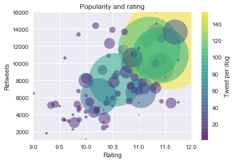

```python
# setting the variables
x= not_all_good_dogs["rating"]
y= not_all_good_dogs["retweets"]
s = not_all_good_dogs["count"] **2
color = not_all_good_dogs["count"]

# plotting
plt.scatter(x,y, s=s, c=color, alpha=0.5, cmap="viridis")
plt.colorbar(label="Tweet per dog")
plt.xlabel("Rating")
plt.ylabel("Retweets")
plt.xlim(9,12)
plt.ylim(1000, 16000)
plt.title("Popularity and rating")
# saving plot for the pdf-document
plt.savefig("dogs.png")
```